# Analiza retelelor in R

Nicula Florin (Gr 406), Orosanu Claudiu (Gr 405)

19 December 2018

# **Analizarea si gestionarea datelor dintr-o retea**

### **Analizarea unei retele**

#### **Preparea datelor**

```r
    library(devtools)
   install_github("DougLuke/UserNetR")
```

Pachetul ‘statnet’ va fi folosit pentru analizarea retelei Moreno. Moreno este o retea ce modeleaza relatiile de prietenie dintre copii de clasa a 4 a.

```r
library(statnet)
library(UserNetR)
data(Moreno)
```

#### **Simpla vizualizare a datelor**

Pentru a vizuliza o retea simpla vom crea o retea care va arata conexiunile dintre membrii acestia bazata pe sex-ul lor

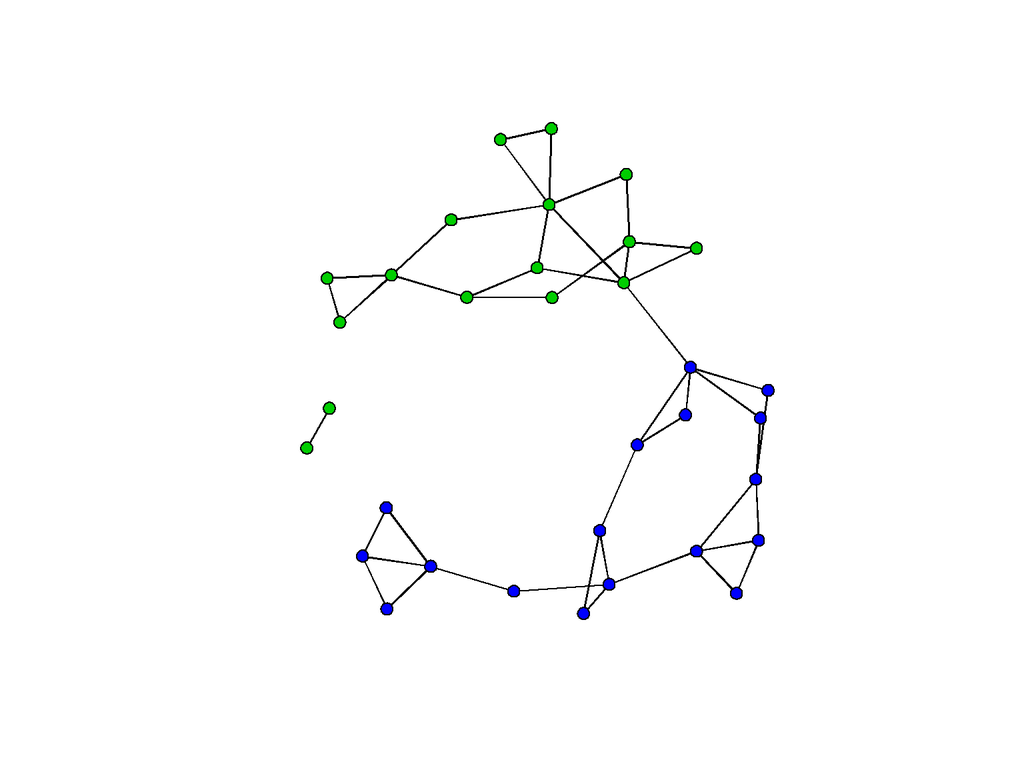

```r
gender <- Moreno %v% "gender"
plot(Moreno, vertex.col = gender + 2, vertex.cex = 1.2)
```

#### **Descrierea functiilor de baza**

Determinarea dimensiunii retelei

```r
network.size(Moreno)
```

```
## [1] 33
```

Pentru a afla mai multe informatii desprea retea putem folosi functia ‘summary’.Setand proprietatea print.adj cu fals oprim afisarea informatiilor despre adiacente

```r
summary(Moreno, print.adj = FALSE)
```

```
## Network attributes:
##   vertices = 33
##   directed = FALSE
##   hyper = FALSE
##   loops = FALSE
##   multiple = FALSE
##   bipartite = FALSE
##  total edges = 46
##    missing edges = 0
##    non-missing edges = 46
##  density = 0.08712121
##
## Vertex attributes:
##
##  gender:
##    numeric valued attribute
##    attribute summary:
##    Min. 1st Qu.  Median    Mean 3rd Qu.    Max.
##   1.000   1.000   2.000   1.515   2.000   2.000
##   vertex.names:
##    character valued attribute
##    33 valid vertex names
##
## No edge attributes
```

```r
den_hand <- 2*46/(33*32)
den_hand
```

```
## [1] 0.08712121
```

```r
gden(Moreno)
```

```
## [1] 0.08712121
```

O retea poate fi impartita in mai multe grupe(componente), care sunt alcatuite in R pe baza conexiunii dintre noduri.

```r
components(Moreno)
```

[output not shown]

```
## [1] 2
```

Pe langa dimensiunea generala a unei retele, o caracteristica mai importanta este faptul cat de compacta este o retea. Aceasta caracteristica este data de diametrul retlei. Diametrul este dat de calea cea mai lunga dintre dintre caile cele mai scurte care conecteaza nodurile retelei. Asta inseamna ca diametrul relfecta cazul cel mai rau pentru a transmite date de-a lungul retelei. Extragem cea mai mare componenta din reteau Moreno(care contine 31 de noduri conectate) intr-o noua matrice. Caile cele mai scurte sunt calculate de functia ‘geodist()’. Maximul cailor cele mai scurte este extras’#obtinandu-se diametrul retelei.

```r
lgc <- component.largest(Moreno,result="graph")
```

[output not shown]

```r
gd <- geodist(lgc)
max(gd$gdist)
```

```
## [1] 11
```

#### **Coeficientul de clusterizare**

Coeficientul de clusterizare este dat de transitivitatea retelei, adica procentul de triunghiuri create intre nodurile retelei. Transitivitatea este calculata de functia ‘gtrans’.

```r
gtrans(Moreno,mode="graph")
```

```
## [1] 0.2857143
```

### **Gestionarea datelor dintr-o retea**

#### **Structuri de date pentru o retea**

O modalitate de a descrie datele din retea este de a le aranja intr-o matrice. Acest tip de matrice se numeste’sociomatrix’, in care gasim valori doar de 0 si 1 (1 reprezantand existenta legaturi intre doua noduri, iar 0 opusul). ‘Edge lists’ sunt liste in care contin doua coloane, prima coloana cotine sursa muchiei retelei, iar cea de a doua contine destinatia. Acest lucru face ca listele care contin muchii sa fie alese in detrimentul ‘sociomatrix’ cand vine vorba de retele mari.Obiectele reprezinta un alt mod de a stoca date despre o retea cand vine vorba de date complexe. Acestea pot contine panala 5 tipuri diferite de date: noduri(lista nodurilor din retea), legaturi (lista legaturilor din retea), atributele nodurilor, atributele legaturilor si metadata (contine informatii suplimentare despre retea).

#### **Creare si gestionarea obiectelor intr-o retea**

Pentru a crea o un obiect al unei retele folosim functia ‘network()’, dar mai intai trebui creata o matrice de adiacenta

```r
netmat1 <- rbind(c(0,1,1,0,0),
                 c(0,0,1,1,0),
                 c(0,1,0,0,0),
                 c(0,0,0,0,0),
                 c(0,0,1,0,0))
rownames(netmat1) <- c("A","B","C","D","E")
colnames(netmat1) <- c("A","B","C","D","E")
net1 <- network(netmat1,matrix.type="adjacency")
class(net1)
```

```
## [1] "network"
```

```r
summary(net1)
```

```
## Network attributes:
##   vertices = 5
##   directed = TRUE
##   hyper = FALSE
##   loops = FALSE
##   multiple = FALSE
##   bipartite = FALSE
##  total edges = 6
##    missing edges = 0
##    non-missing edges = 6
##  density = 0.3
##
## Vertex attributes:
##   vertex.names:
##    character valued attribute
##    5 valid vertex names
##
## No edge attributes
##
## Network adjacency matrix:
##   A B C D E
## A 0 1 1 0 0
## B 0 0 1 1 0
## C 0 1 0 0 0
## D 0 0 0 0 0
## E 0 0 1 0 0
```

Vizualizarea retelei noi create:

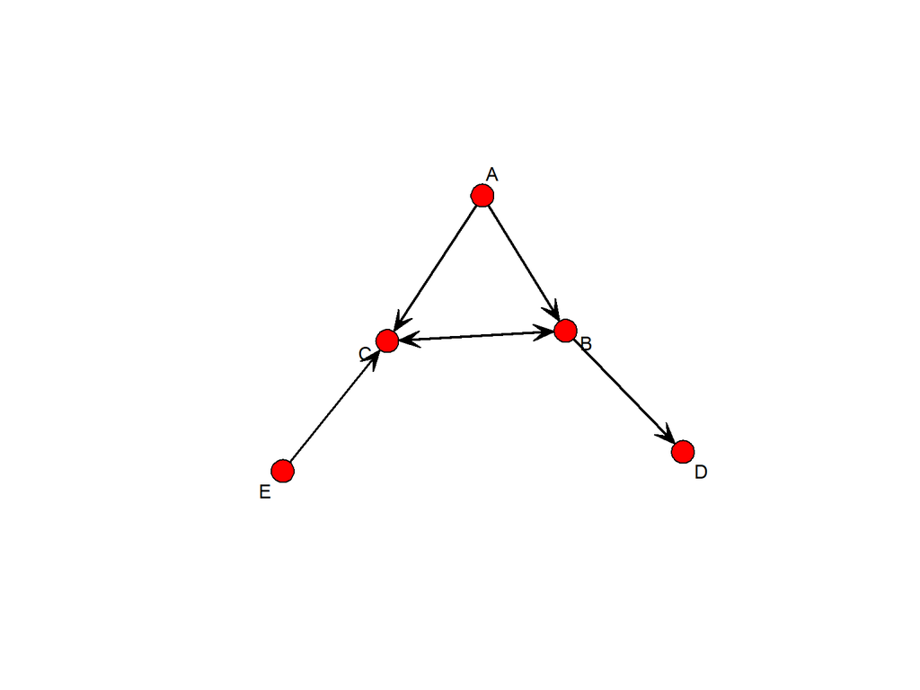

```r
gplot(net1, vertex.col = 2, displaylabels = TRUE)
```

In libraria ‘statnet’ contine si functii prin care o retea poate fi inversate in alte tipuri de date

```r
as.sociomatrix(net1)
```

```
##   A B C D E
## A 0 1 1 0 0
## B 0 0 1 1 0
## C 0 1 0 0 0
## D 0 0 0 0 0
## E 0 0 1 0 0
```

```r
class(as.sociomatrix(net1))
```

```
## [1] "matrix"
```

```r
all(as.matrix(net1) == as.sociomatrix(net1))
```

```
## [1] TRUE
```

```r
as.matrix(net1,matrix.type = "edgelist")
```

```
##      [,1] [,2]
## [1,]    1    2
## [2,]    3    2
## [3,]    1    3
## [4,]    2    3
## [5,]    5    3
## [6,]    2    4
## attr(,"n")
## [1] 5
## attr(,"vnames")
## [1] "A" "B" "C" "D" "E"
```

-setam atribute(sex-ul membrilor) pentru nodurile retelei:

```r
set.vertex.attribute(net1, "gender", c("F", "F", "M", "F", "M"))
```

-vom seta un vector numeric ca si atribut

```r
net1 %v% "alldeg" <- degree(net1)
list.vertex.attributes(net1)
```

```
## [1] "alldeg"       "gender"       "na"           "vertex.names"
```

-afisarea atributului ‘gender’

```r
get.vertex.attribute(net1, "gender")
```

```
## [1] "F" "F" "M" "F" "M"
```

```r
net1 %v% "alldeg"
```

```
## [1] 2 4 4 1 1
```

-setam un numar ales aleator fiecarei muchii din retea si afisam aceasta informatie

```r
list.edge.attributes(net1)
```

```
## [1] "na"
```

```r
set.edge.attribute(net1,"rndval",
                   runif(network.size(net1),0,1))
list.edge.attributes(net1)
```

```
## [1] "na"     "rndval"
```

```r
summary(net1 %e% "rndval")
```

```
##    Min. 1st Qu.  Median    Mean 3rd Qu.    Max.
## 0.03318 0.29337 0.50598 0.47755 0.58803 0.98229
```

```r
summary(get.edge.attribute(net1,"rndval"))
```

```
##    Min. 1st Qu.  Median    Mean 3rd Qu.    Max.
## 0.03318 0.29337 0.50598 0.47755 0.58803 0.98229
```

#### **Importarea datelor intr-o retea***

Cream o lista cu muchii pe care o salvam intr-un fisier CSV dupa care citim din fisier si il transformam intr-un obiect

```r
library(statnet)

netmat3 <- rbind(c("A","B"),
                 c("A","C"),
                 c("B","C"),
                 c("B","D"),
                 c("C","B"),
                 c("E","C"))
net.df <- data.frame(netmat3)
net.df
```

```
##   X1 X2
## 1  A  B
## 2  A  C
## 3  B  C
## 4  B  D
## 5  C  B
## 6  E  C
```

```r
write.csv(net.df, file = "MyData.csv",
          row.names = FALSE)
net.edge <- read.csv(file="MyData.csv")
net_import <- network(net.edge,
                      matrix.type="edgelist")
summary(net_import)
```

```
## Network attributes:
##   vertices = 5
##   directed = TRUE
##   hyper = FALSE
##   loops = FALSE
##   multiple = FALSE
##   bipartite = FALSE
##  total edges = 6
##    missing edges = 0
##    non-missing edges = 6
##  density = 0.3
##
## Vertex attributes:
##   vertex.names:
##    character valued attribute
##    5 valid vertex names
##
## No edge attributes
##
## Network adjacency matrix:
##   A B C D E
## A 0 1 1 0 0
## B 0 0 1 1 0
## C 0 1 0 0 0
## D 0 0 0 0 0
## E 0 0 1 0 0
```

```r
gden(net_import)
```

```
## [1] 0.3
```

#### **Operatii pe datele dintr-o retea***

##### **Filtrarea retelelor***

Intr-un obiect al retelei putem gasi caracteristici ale nodurilor salvate ca atribute ale muchiilor. Aceasta informatie poate fi folosita pentru a selecta sub retele pentru analiza get.inducedSubgraph() este o functie care returneaza un nou obiect al retelei care este bazat pe criteriul de filtrare

```r
n1F <- get.inducedSubgraph(net1,
                           which(net1 %v% "gender" == "F"))
n1F[,]
```

```
##   A B D
## A 0 1 0
## B 0 0 1
## D 0 0 0
```

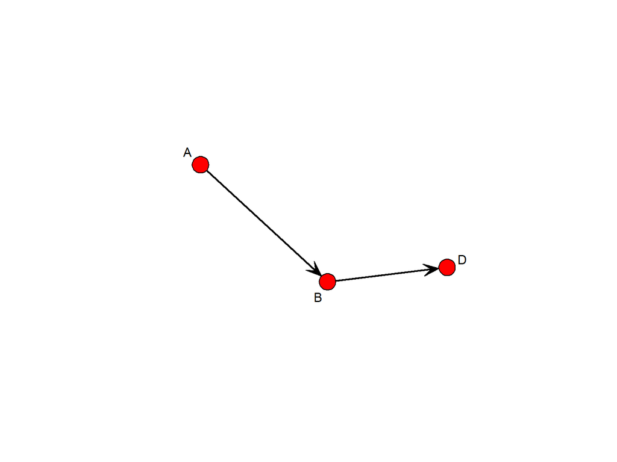

```r
gplot(n1F,displaylabels=TRUE)
```

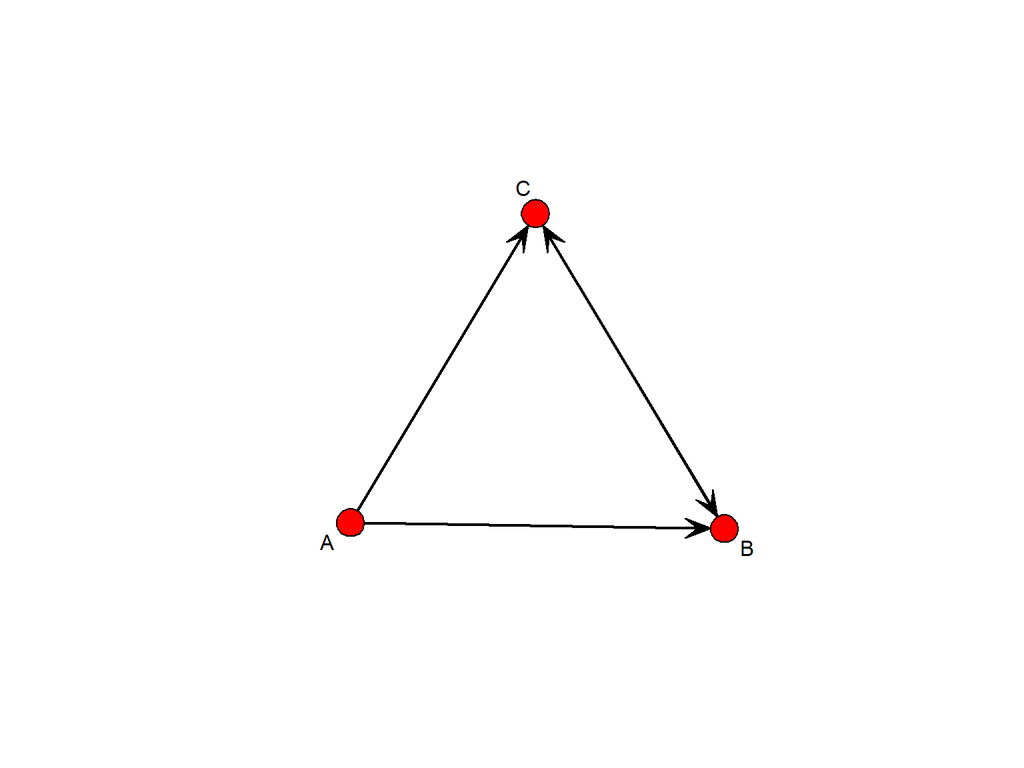

```r
deg <- net1 %v% "alldeg"
n2 <- net1 %s% which(deg > 1)
gplot(n2,displaylabels=TRUE)
```

##### **Stergearea nodurilor izolate*** Folosind setul de date ‘ICTS’ din pachetul ‘UserNetR’, a carei retele contine date despre oameni de stiinta. Utilizand functia ‘isolates’ putem detecta numarul de noduri izolate.

```r
data(ICTS_G10)
gden(ICTS_G10)
```

```
## [1] 0.01120566
```

```r
length(isolates(ICTS_G10))
```

```
## [1] 96
```

Stergerea acestora se face utilizand functia ‘delete.vertices’ care nu returneaza un obiect ci opereaza direct pe setul de date pe care il primeste. Din acest moriv e mai sigur la copiem datele intr-o variabila

```r
n3 <- ICTS_G10
delete.vertices(n3,isolates(n3))
gden(n3)
```

```
## [1] 0.01728876
```

```r
length(isolates(n3))
```

```
## [1] 0
```

##### **Filtrarea retelelor***

Pentru filtrarea bazata pe valorile muchiilor folosim o alta retea numita ‘DHHS’ care contine date despre experti in controlul tutunului care lucreza in 11 agentii diferite. Dupa cum se poate observa aceasta retea este foarte densa si greu de interpretat.

```r
data(DHHS)
d <- DHHS
gden(d)
```

```
## [1] 0.312369
```

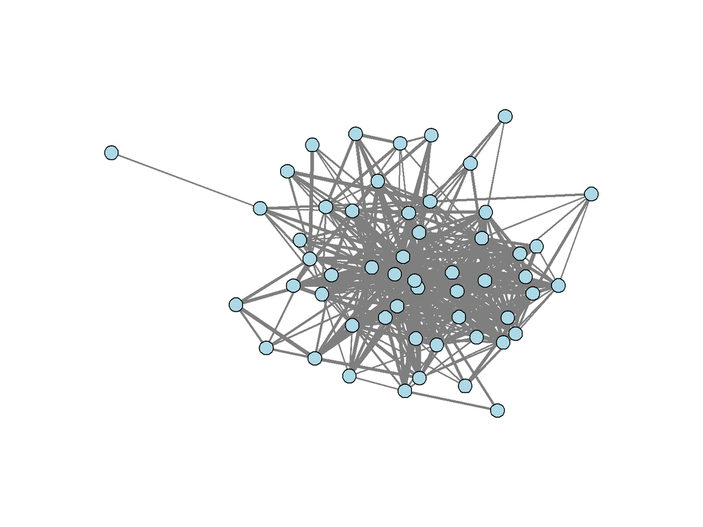

```r
op <- par(mar = rep(0, 4))
gplot(d,gmode="graph",
      edge.lwd=d %e%'collab',edge.col="grey50",vertex.col="lightblue", vertex.cex=1.0,vertex.sides=20)
```

```r
par(op)
```

Pentru a avea o imagine clara asupra retelei o vom filtra dupa valoriile muchiilor. Primul lucru pe care il vom face este sa extragem primii 6 membrii din retea pentru a determina legaturile din acestia.

```r
as.sociomatrix(d)[1:6,1:6]
```

```
##        ACF-1 ACF-2 AHRQ-1 AHRQ-2 AHRQ-3 AHRQ-4
## ACF-1      0     1      0      0      0      0
## ACF-2      1     0      0      0      0      0
## AHRQ-1     0     0      0      1      1      1
## AHRQ-2     0     0      1      0      1      1
## AHRQ-3     0     0      1      1      0      1
## AHRQ-4     0     0      1      1      1      0
```

```r
list.edge.attributes(d)
```

```
## [1] "collab" "na"
```

```r
as.sociomatrix(d,attrname="collab")[1:6,1:6]
```

```
##        ACF-1 ACF-2 AHRQ-1 AHRQ-2 AHRQ-3 AHRQ-4
## ACF-1      0     1      0      0      0      0
## ACF-2      1     0      0      0      0      0
## AHRQ-1     0     0      0      3      3      3
## AHRQ-2     0     0      3      0      3      2
## AHRQ-3     0     0      3      3      0      3
## AHRQ-4     0     0      3      2      3      0
```

Vom observa ca exista 447 de legaturi in acest set de date:

```r
table(d %e%"collab")
```

```
##
##   1   2   3   4
## 163 111  94  79
```

Dintre care 163 reprezinta schimbul de informatii neoficiale, 111 sunt legaturi informale, 94 sunt legaturi formale pe un singur proiect iar restul de 79 sunt legaturi care reprezinta legaturi intre membrii care au lucrat impreuna pe mai multe proiecte. Vom extrage intr-o matrice toate colaborarile dupa care vom filtra legaturile care ne intereseaza, adica vo inlocui legaturile cu valoarea 1 sau 2 cu 0.

```r
d.val <- as.sociomatrix(d,attrname="collab")
d.val[d.val < 3] <- 0
d.filt <- as.network(d.val, directed=FALSE,
                     matrix.type="a",ignore.eval=FALSE,
                     names.eval="collab")
summary(d.filt,print.adj=FALSE)
```

```
## Network attributes:
##   vertices = 54
##   directed = FALSE
##   hyper = FALSE
##   loops = FALSE
##   multiple = FALSE
##   bipartite = FALSE
##  total edges = 173
##    missing edges = 0
##    non-missing edges = 173
##  density = 0.1208945
##
## Vertex attributes:
##   vertex.names:
##    character valued attribute
##    54 valid vertex names
##
## Edge attributes:
##
##  collab:
##    numeric valued attribute
##    attribute summary:
##    Min. 1st Qu.  Median    Mean 3rd Qu.    Max.
##   3.000   3.000   3.000   3.457   4.000   4.000
```

```r
gden(d.filt)
```

```
## [1] 0.1208945
```

Vom observa ca doar 173 legaturi corespund cu nivelul 3 si 4 de colaborare. Acum putem observa o retea mai mica:

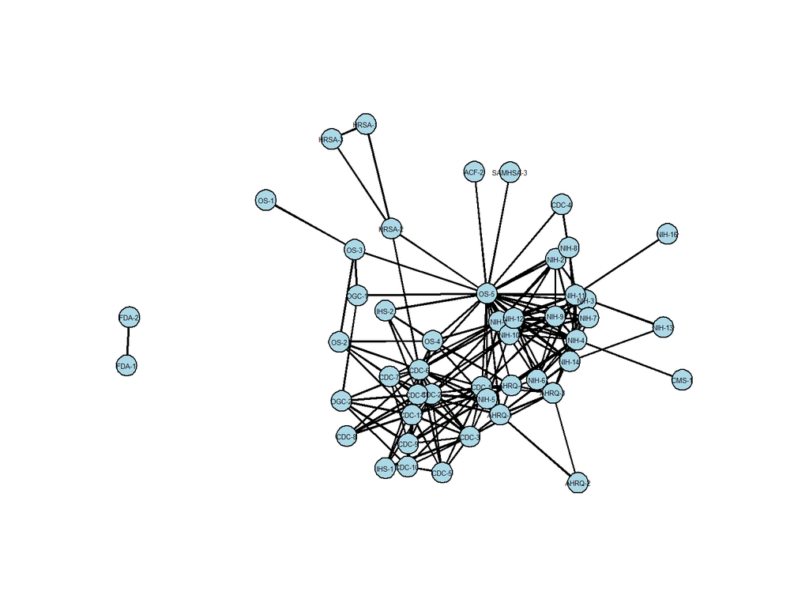

```r
op <- par(mar = rep(0, 4))
gplot(d.filt,gmode="graph",displaylabels=TRUE,
      vertex.col="lightblue",vertex.cex=1.3,
      label.cex=0.4,label.pos=5, displayisolates=FALSE)
```

```r
par(op)
```

Transformarea unei retele orientate la o retea neorientata in R putem folosi functia ‘symmetrize()’. Intr-o matrice de tip ‘sociomatrix’ daca datele sunt simetrice in jurul diagonalei indica faptul ca legaturile sunt neorientate. Utilizarea functie este destul de simpla cu exceptia faptului ca returneaza o matrice de tipul ‘sociomatrix’ sau o lista de muchii. Putem gestiona acest lucru trebuie ca rezultatul sa fie transformat intr-un obiect. Parametrul ‘rule’ ne permite sa alegeme modul in care simetrizam legaturile. Valoare ‘weak’ a cestui parametru corespunde operatorului logic sau (OR) unde noile legaturile sunt create intre noduri indiferent de orientarea precendeta a acestora. In schimb valoare ‘strong’ corespunde cu operatorul logic si (AND).

```r
net1mat <- symmetrize(net1,rule="weak")
net1mat
```

```
##      [,1] [,2] [,3] [,4] [,5]
## [1,]    0    1    1    0    0
## [2,]    1    0    1    1    0
## [3,]    1    1    0    0    1
## [4,]    0    1    0    0    0
## [5,]    0    0    1    0    0
```

```r
net1symm <- network(net1mat,matrix.type="adjacency")
network.vertex.names(net1symm) <- c("A","B","C","D","E")
summary(net1symm)
```

```
## Network attributes:
##   vertices = 5
##   directed = TRUE
##   hyper = FALSE
##   loops = FALSE
##   multiple = FALSE
##   bipartite = FALSE
##  total edges = 10
##    missing edges = 0
##    non-missing edges = 10
##  density = 0.5
##
## Vertex attributes:
##   vertex.names:
##    character valued attribute
##    5 valid vertex names
##
## No edge attributes
##
## Network adjacency matrix:
##   A B C D E
## A 0 1 1 0 0
## B 1 0 1 1 0
## C 1 1 0 0 1
## D 0 1 0 0 0
## E 0 0 1 0 0
```

# **Vizualizarea retelelor**

## **1. Tehnici de plotare si layout**

Reprezentarea vizuala a retelelor este o provocare. Numarul de moduri in care o retea poate fi reprezentata vizual este practic infinit. Un grafic sugestiv va transmite informatiile importante despre retea, cum ar fi structura generala, locatia actorilor importanti din retea, prezenta unor subgrupuri distinctive. De asemenea, informatia irelevanta trebuie sa fie cat mai putina.

```r
library(statnet)
library(UserNetR)
data(Moreno)
```

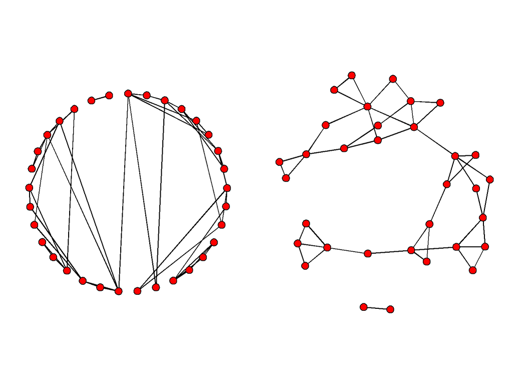

```r
op <- par(mar = rep(0, 4),mfrow=c(1,2))
plot(Moreno,mode="circle",vertex.cex=1.5)
plot(Moreno,mode="fruchtermanreingold",vertex.cex=1.5)
```

```r
par(op)
```

Moreno este o retea ce modeleaza relatiile de prietenie dintre copii de clasa a 4 a.

Lungimea muchiilor in aceste grafice nu are nicio insemnatate. Alegerea la intamplare a acestor lungimi poate induce in eroare.

### **Principii estetice in reprezentarea retelelor**

- Cat mai putine intersectii ale muchiilor
- Simetria nodurilor in retea trebuie sa fie cat mai mare
- Lungimea muchiilor trebuie sa varieze cat mai putin
- Atunci cand doua muchii se intersecteaza, unghiul format trebuie sa fie cat mai mare
- Minimizarea spatiului pentru reprezentarea retelei

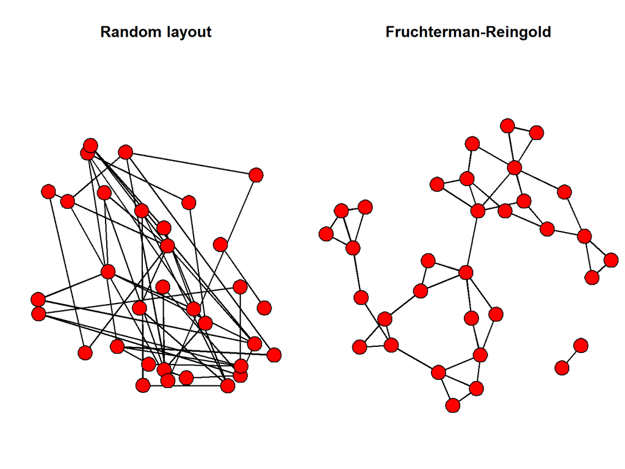

```r
op <- par(mar = c(0,0,4,0),mfrow=c(1,2))
gplot(Moreno,gmode="graph",mode="random",vertex.cex=1.5,main="Random layout")
gplot(Moreno,gmode="graph",mode="fruchtermanreingold",vertex.cex=1.5,main="Fruchterman-Reingold")
```

```r
par(op)
```

### **Algoritmi si metode de plotare**

In libraria *statnet*, exista doua functii prin care se poate realiza un grafic al unei retele: *plot* si *gplot*.

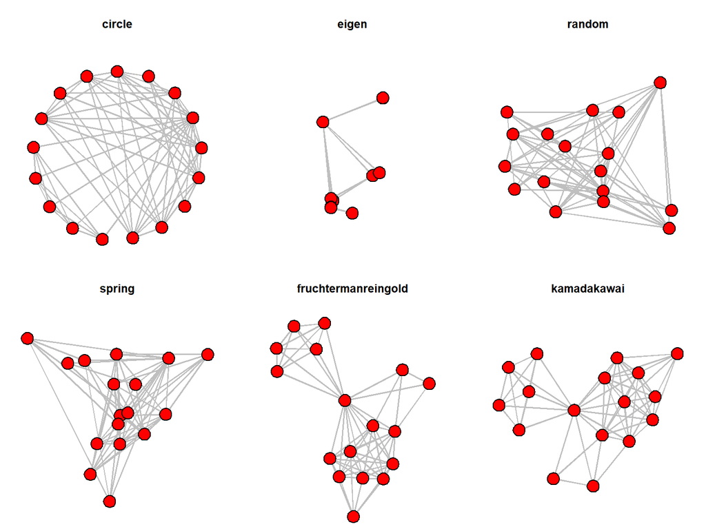

```r
op <- par(mar=c(0,0,4,0),mfrow=c(2,3))

gplot(Bali,gmode="graph",edge.col="grey75",vertex.cex=1.5,mode='circle',main="circle")

gplot(Bali,gmode="graph",edge.col="grey75",vertex.cex=1.5,mode='eigen',main="eigen")

gplot(Bali,gmode="graph",edge.col="grey75",vertex.cex=1.5,mode='random',main="random")

gplot(Bali,gmode="graph",edge.col="grey75",vertex.cex=1.5,mode='spring',main="spring")

gplot(Bali,gmode="graph",edge.col="grey75",vertex.cex=1.5,mode='fruchtermanreingold',main='fruchtermanreingold')

gplot(Bali,gmode="graph",edge.col="grey75",vertex.cex=1.5,mode='kamadakawai',main='kamadakawai')
```

```r
par(op)
```

#### **Control mai ridicat asupra layout-ului**

R ne ofera posibilitatea de a specifica coordonatele fiecarui nod, atunci cand cream un grafic al unei retele.

Parametrul **coord** din functia **plot** este folosit in scopul acesta. El ar trebui sa primeasca o matrice cu doua coloane (X si Y), unde fiecare rand reprezinta coordonatele unui nod. De asemenea, functia **gplot**, atunci cand este apelata, intoarce coordonatele nodurilor, iar acestea pot fi salvate intr-o variabila.

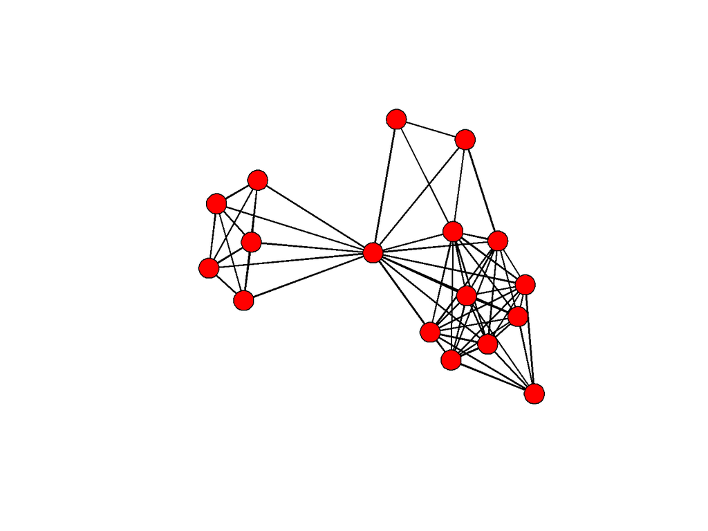

```r
mycoords1 <- gplot(Bali,gmode="graph",vertex.cex=1.5)
```

```r
mycoords1
```

```
##                 x          y
##  [1,]  6.25294023  -6.896441
##  [2,]  5.41094277  -4.273811
##  [3,]  6.96326607  -8.032280
##  [4,]  3.02211183  -7.204440
##  [5,]  6.77416039  -8.858234
##  [6,]  5.09425039  -6.654634
##  [7,]  3.62730193  -3.746831
##  [8,]  4.50052498  -9.260961
##  [9,]  5.04333737  -9.981135
## [10,] -0.32938523  -8.437516
## [11,] -1.03081489  -5.934334
## [12,] -0.13084897  -6.927767
## [13,] -1.23093912  -7.601980
## [14,]  0.03399467  -5.324564
## [15,]  5.44495687  -8.319200
## [16,]  7.19898564 -10.856395
## [17,]  5.99102865  -9.570082
```

```r
mycoords2 <- mycoords1
mycoords2[,2] <- mycoords1[,2]*1.5
mycoords2
```

```
##                 x          y
##  [1,]  6.25294023 -10.344662
##  [2,]  5.41094277  -6.410717
##  [3,]  6.96326607 -12.048419
##  [4,]  3.02211183 -10.806660
##  [5,]  6.77416039 -13.287351
##  [6,]  5.09425039  -9.981950
##  [7,]  3.62730193  -5.620247
##  [8,]  4.50052498 -13.891441
##  [9,]  5.04333737 -14.971702
## [10,] -0.32938523 -12.656275
## [11,] -1.03081489  -8.901501
## [12,] -0.13084897 -10.391651
## [13,] -1.23093912 -11.402971
## [14,]  0.03399467  -7.986846
## [15,]  5.44495687 -12.478800
## [16,]  7.19898564 -16.284592
## [17,]  5.99102865 -14.355123
```

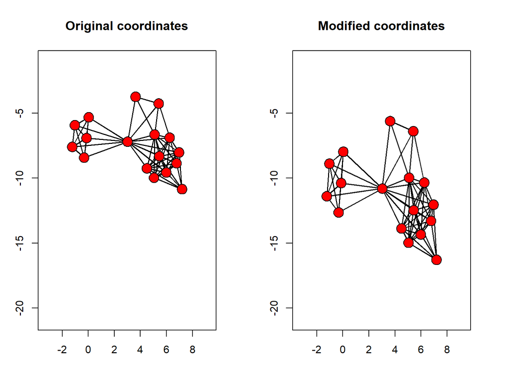

```r
op <- par(mar=c(4,3,4,3),mfrow=c(1,2))

gplot(Bali,gmode="graph",vertex.cex=1.5,
      coord=mycoords1, suppress.axes = FALSE,
      ylim=c(min(mycoords2[,2])-1,max(mycoords2[,2])+1),
      main="Original coordinates")

gplot(Bali,gmode="graph",vertex.cex=1.5,
      coord=mycoords2,suppress.axes = FALSE,
      ylim=c(min(mycoords2[,2])-1,max(mycoords2[,2])+1),
      main="Modified coordinates")
```

```r
par(op)
```

## **2. Design sugestiv in realizarea graficelor**

Obiectivul principal al unui design eficace este de a dezvalui trasaturile importante ale unei retele si informatia continuta in aceasta. Pentru atingerea acestui scop, librariile *statnet* si *igraph* ofera control programatic asupra aspectului oricarui element din graficul retelei.

> Excelenta in design-ul grafic presupune transmiterea unui numar cat mai mare de idei intr-un timp cat mai scurt, folosind cat mai putina cerneala si spatiu. - Edward Tufte

### **Culoarea nodurilor**

Implicit, *statnet* foloseste cercuri de culoare rosie pentru a reprezenta nodurile retelei. Culoarea nodurilor se poate configura prin optiunea **vertex.col** a functiei **gplot**. Optiunea *gmode* este “graph” pentru a nu interpreta graful ca fiind orientat.

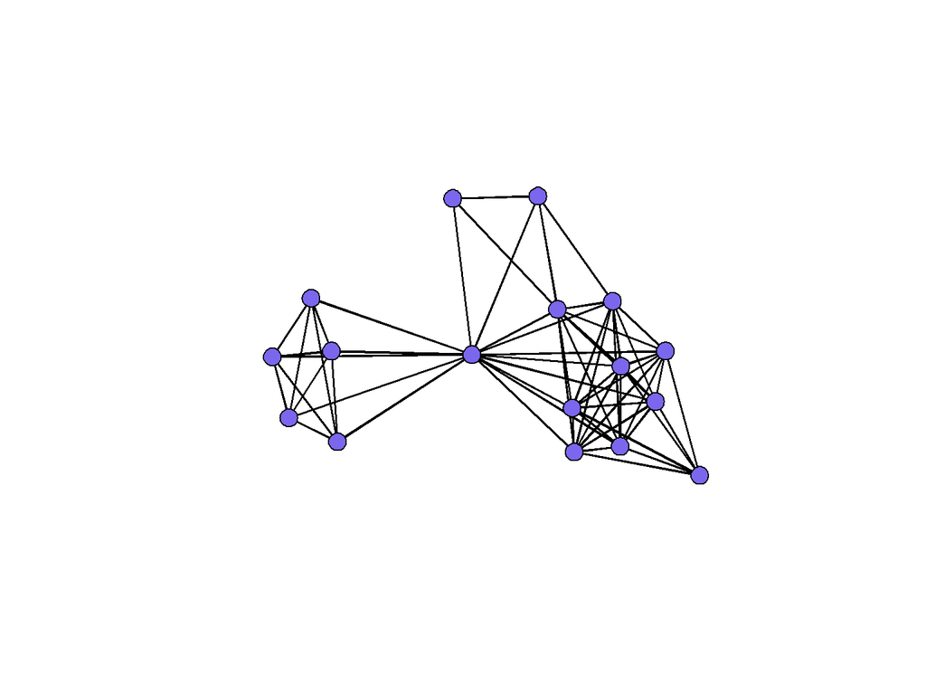

```r
gplot(Bali,vertex.col="slateblue2",gmode="graph")
```

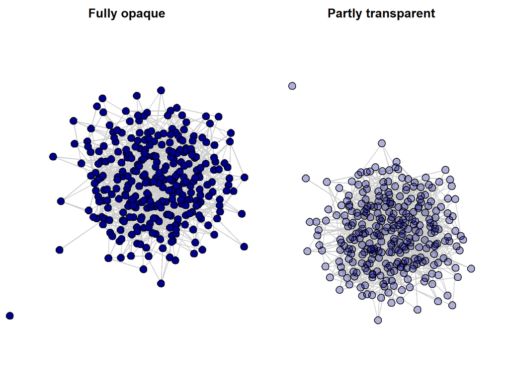

```r
ndum <- rgraph(300,tprob=0.025,mode="graph")

op <- par(mar = c(0,0,2,0),mfrow=c(1,2))

gplot(ndum,gmode="graph",
      vertex.cex=2, vertex.col=rgb(0,0,139,maxColorValue=255),
      edge.col="grey80",edge.lwd=0.5,
      main="Fully opaque")

gplot(ndum,gmode="graph",
      vertex.cex=2,vertex.col=rgb(0,0,139,alpha=80,maxColorValue=255),
      edge.col="grey80",edge.lwd=0.5,
      main="Partly transparent")
```

```r
par(op)
```

Reteaua Bali contine atributul *role* pentru fiecare nod, care reprezinta rolul fiecarui membru in gruparea terorita (BM - bomb maker, CT - command team, etc.). Reprezentarea fiecarui rol cu o culoare diferita poate ilustra mai bine informatia din interiorul retelei.

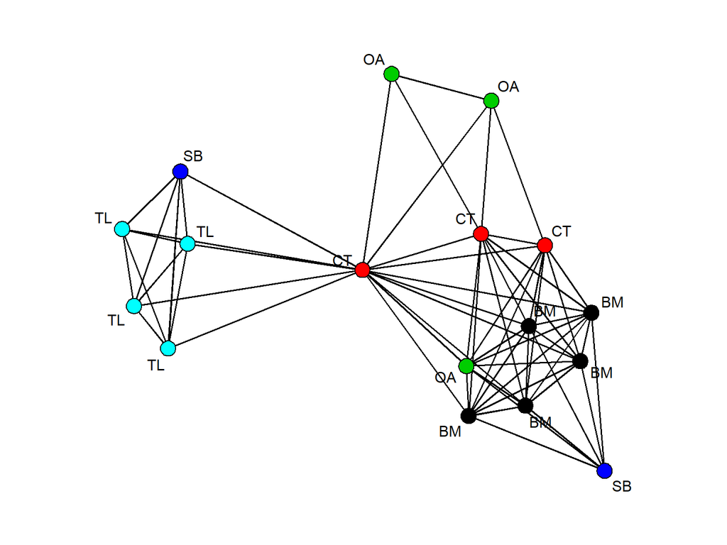

```r
rolelab <- get.vertex.attribute(Bali,"role")
op <- par(mar=c(0,0,0,0))
plot(Bali,usearrows=FALSE,vertex.cex=1.5,label=rolelab,displaylabels=T,vertex.col="role")
```

```r
par(op)
```

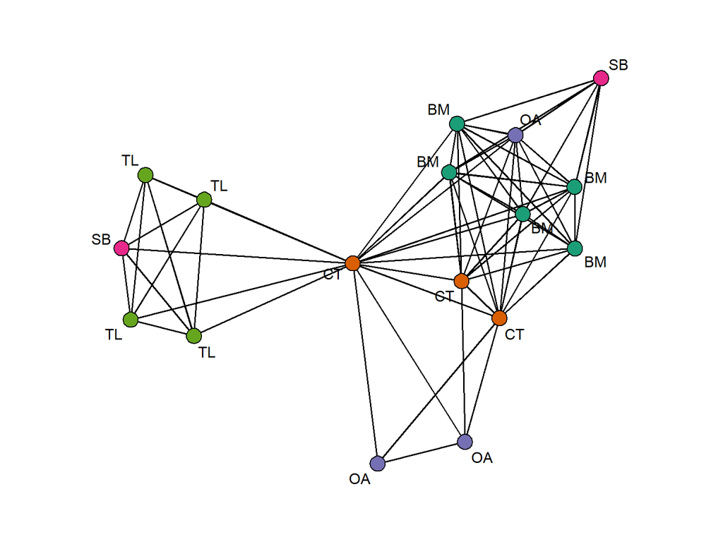

```r
op <- par(mar=c(0,0,0,0))
my_pal <- brewer.pal(5,"Dark2")
rolecat <- as.factor(get.vertex.attribute(Bali,"role"))
plot(Bali,vertex.cex=1.5,label=rolelab,displaylabels=T,vertex.col=my_pal[rolecat])
```

```r
par(op)
```

### **Forma nodurilor**

Pe langa culoarea nodurilor, putem controla si forma lor. Acest lucru e util atunci cand sunt putine categorii de noduri.

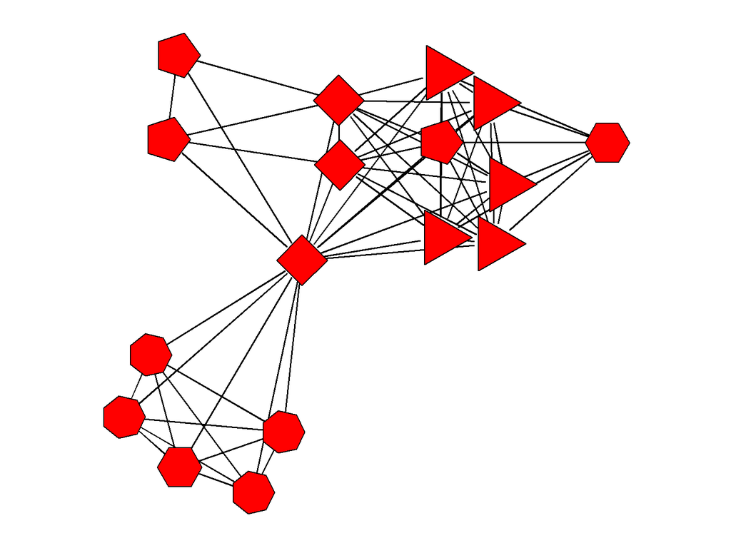

```r
op <- par(mar=c(0,0,0,0))
sidenum <- 3:7
plot(Bali,usearrows=FALSE,vertex.cex=4,displaylabels=F,vertex.sides=sidenum[rolecat])
```

```r
par(op)
```

### **Marimea nodurilor**

Marimea nodurilor este controlata prin optiunea **vertex.cex** a functiilor *gplot* si *plot*.

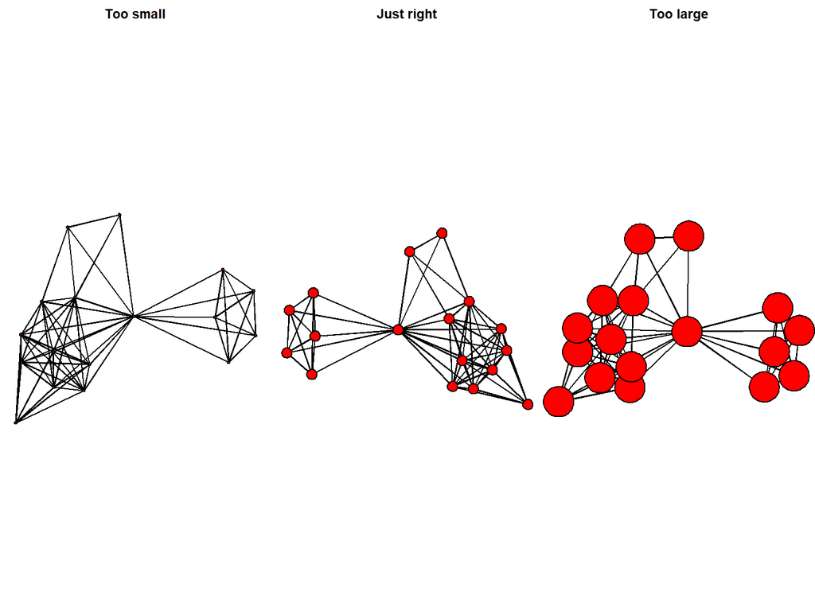

```r
op <- par(mar = c(0,0,2,0),mfrow=c(1,3))
plot(Bali,vertex.cex=0.5,main="Too small")
plot(Bali,vertex.cex=2,main="Just right")
plot(Bali,vertex.cex=6,main="Too large")
```

```r
par(op)
```

Mai interesanta este reprezentarea nodurilor prin **marimi diferite** penru a reliefa o **caracteristica cantitativa**.

```r
deg <- degree(Bali,gmode="graph")
deg
```

```
##  [1]  9  4  9 15  9 10  3  9  9  5  5  5  5  5  9  6  9
```

Vectorul **deg** care contine gradul fiecarui nod, are valorile prea mari, asa ca vom calcula logaritmul fiecare valori folosind functia **log**.

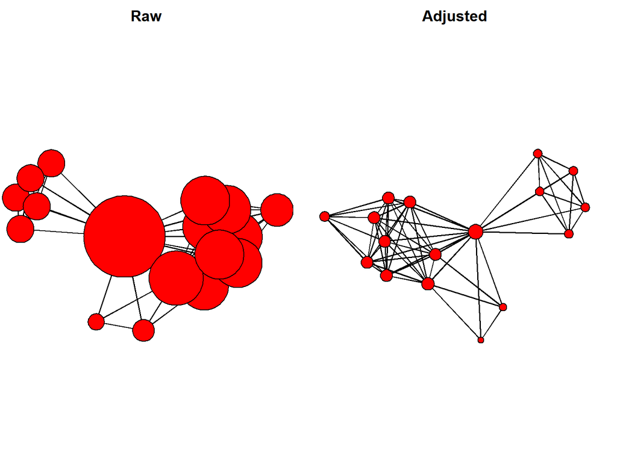

```r
op <- par(mar = c(0,0,2,1),mfrow=c(1,2))
plot(Bali,usearrows=T,vertex.cex=deg,main="Raw")
plot(Bali,usearrows=FALSE,vertex.cex=log(deg),main="Adjusted")
```

```r
par(op)
```

### **Etichete ale nodurilor**

Daca un obiect de tip retea din libraria *statnet* contine atributul *vertex.names* pentru noduri, acesta poate fi folosit pentru a afisa automat etichetele cand se ploteaza graficul.

```r
get.vertex.attribute(Bali,"vertex.names")
```

```
##  [1] "Muklas"   "Amrozi"   "Imron"    "Samudra"  "Dulmatin" "Idris"
##  [7] "Mubarok"  "Husin"    "Ghoni"    "Arnasan"  "Rauf"     "Octavia"
## [13] "Hidayat"  "Junaedi"  "Patek"    "Feri"     "Sarijo"
```

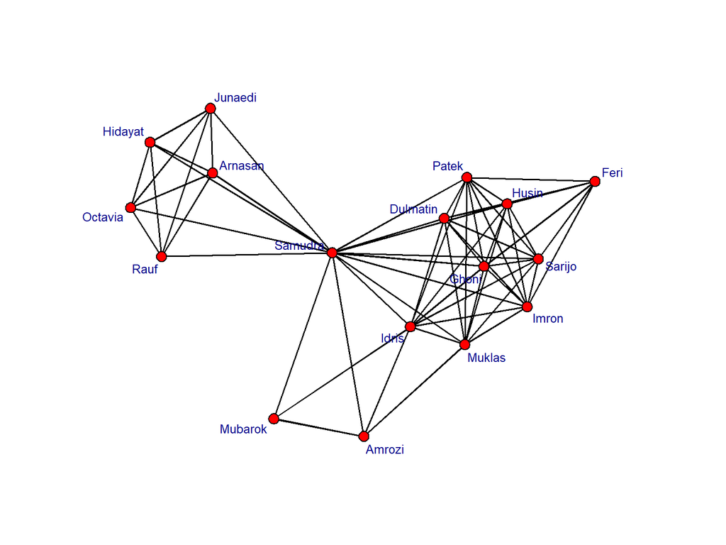

```r
op <- par(mar = c(0,0,0,0))
plot(Bali,displaylabels=TRUE,label.cex=0.8,pad=0.4,label.col="darkblue")
```

```r
par(op)
```

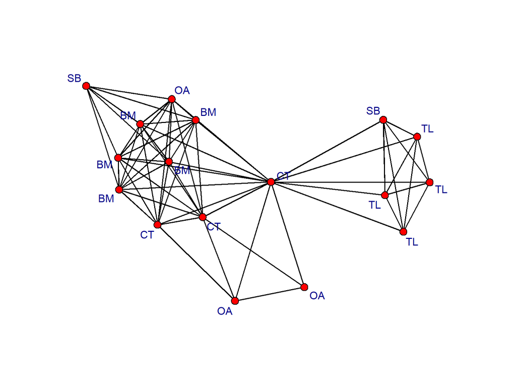

```r
op <- par(mar = c(0,0,0,0))
rolelab <- get.vertex.attribute(Bali,"role")
plot(Bali,usearrows=FALSE,label=rolelab,displaylabels=T,label.col="darkblue")
```

```r
par(op)
```

### **Grosimea muchiilor**

Daca reteaua contine legaturi care au asociate valori cantitative, atunci acestea pot fi reprezentate prin grosimea unei muchii.

Reteaua Bali contine un atribut pentru fiecare muchie, numit **IC**, care simbolizeaza gradul de interactiune dintre cei doi membri ai retelei. Muchiile mai groase reprezinta relatii mai puternice.

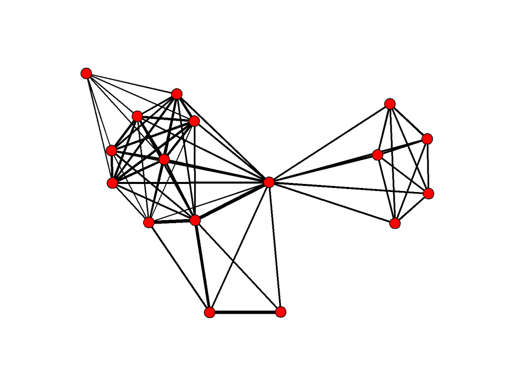

```r
op <- par(mar = c(0,0,0,0))
IClevel <- Bali %e% "IC"
plot(Bali,vertex.cex=1.5,edge.lwd=1.5*IClevel)
```

```r
par(op)
```

### **Culoarea muchiilor**

Spre deosebire de grosimea unei muchii, care transmite o valoare cantitativa, culoarea unei muchii comunica o valoare calitativa a legaturii dintre cele doua noduri.

Intr-o retea sociala:

- muchii verzi - prietenii
- muchii gri - relatii neutre
- muchii rosii - dusmanii

Reteaua Bali nu contine o valoare calitativa asociata muchiilor, asa ca vom crea noi una, pentru a oferi un exemplu.

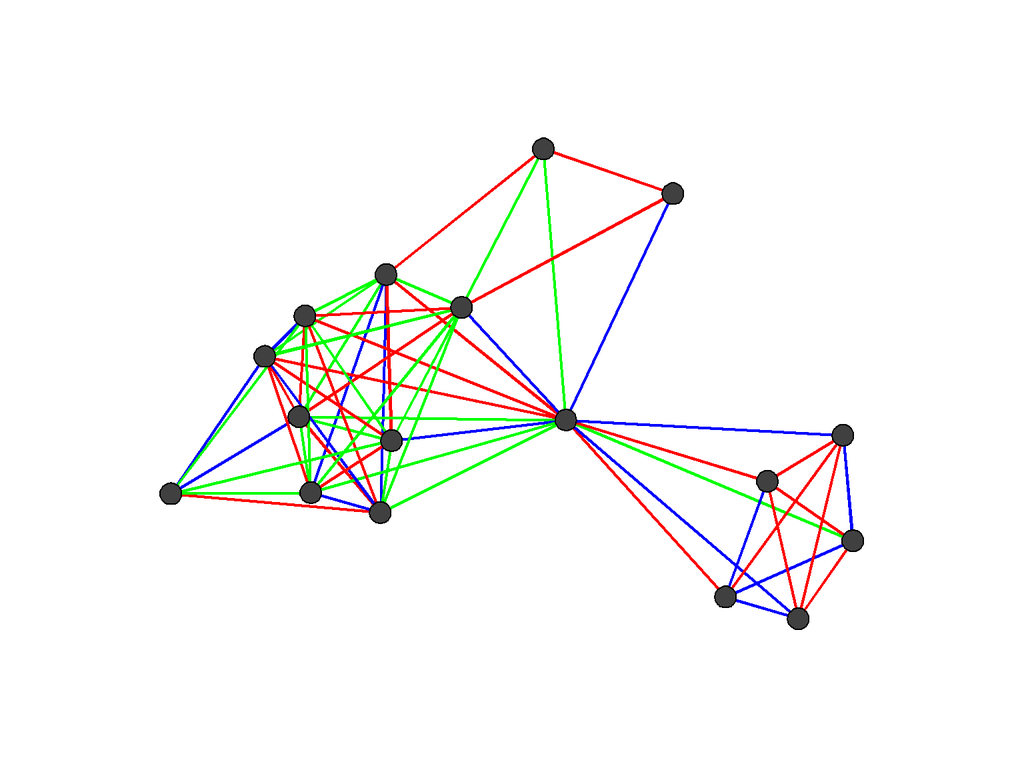

```r
op <- par(mar = c(0,0,0,0))

n_edge <- network.edgecount(Bali)
edge_cat <- sample(1:3,n_edge,replace=T)
linecol_pal <- c("blue","red","green")

plot(Bali,vertex.cex=1.5,vertex.col="grey25",
     edge.col=linecol_pal[edge_cat],
     edge.lwd=2)
```

```r
par(op)
```

### **Tipul muchiilor**

Asemanator culorii unei muchii, tipul acesteia poate comunica informatii calitative. Mergand pe acelasi exemplu, vom simula un atribut al muchiilor si vom plota folosind diferita tipuri de muchii (2-linie intrerupta; 3-linie punctata; 4-linie punctata si intrerupta).

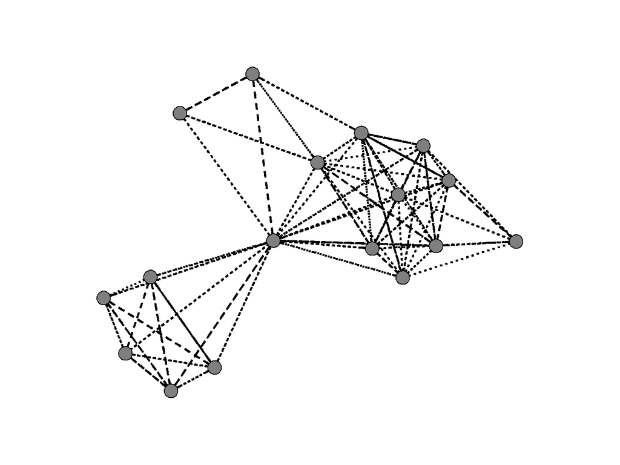

```r
op <- par(mar = c(0,0,0,0))

n_edge <- network.edgecount(Bali)
edge_cat <- sample(1:3,n_edge,replace=T)
line_pal <- c(2,3,4)

gplot(Bali,vertex.cex=0.8,gmode="graph",vertex.col="gray50",
      edge.lwd=1.5,
      edge.lty=line_pal[edge_cat])
```

```r
par(op)
```

### **Legende**

O legenda are rolul de a clarifica informatiile continute in grafic. Functiile de baza de plotare din *statnet* nu ofera aceasta functionalitate, dar putem folosi functia **legend()** din limbajul R.

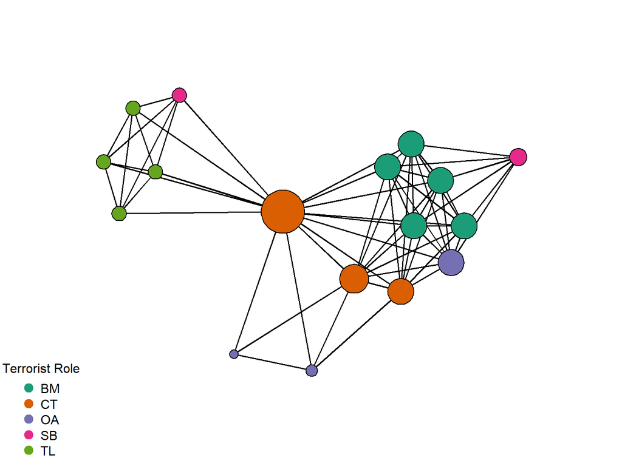

```r
op <- par(mar = c(0,0,0,0))

my_pal <- brewer.pal(5,"Dark2")
rolecat <- as.factor(get.vertex.attribute(Bali,"role"))

plot(Bali,vertex.cex=rescale(deg,1,5),vertex.col=my_pal[rolecat])

legend("bottomleft",
       legend=c("BM","CT","OA","SB","TL"),
       col=my_pal,
       pch=19,
       pt.cex=1.5,
       bty="n",
       title="Terrorist Role")
```

```r
par(op)
```

## **3. Tehnici avansate de plotare a graficelor**

Graficele realizate pana acum, cu ajutorul librariilor *statnet* si *igraph* au fost **statice**. Pentru reprezentarea mai specializata a unor retele, avem nevoie de interactiune.

### **Retele interactive simple in *igraph***

Pachetul *igraph* ofera functia **tkplot()**, prin care se poate configura fiecare element al unui grafic, intr-o maniera interactiva.

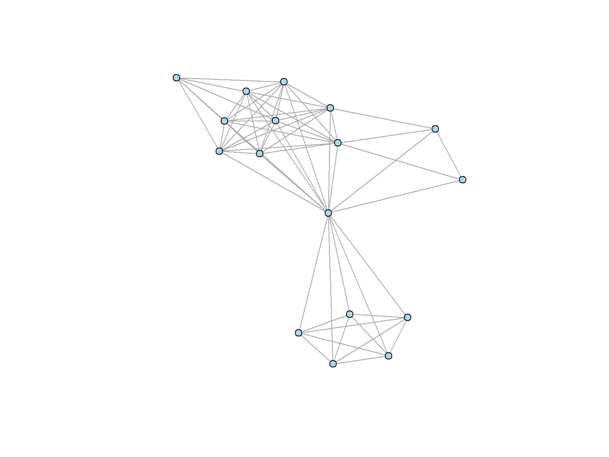

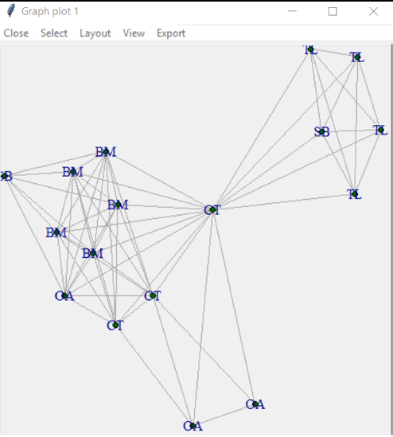

```r
iBali <- asIgraph(Bali)
Coord <- tkplot(iBali, vertex.size=3,
                vertex.label=V(iBali)$role,
                vertex.color="darkgreen")

# Edit plot in Tk graphics window before
# running next two commands.
MCoords <- tkplot.getcoords(Coord)
plot(iBali, layout=MCoords, vertex.size=5,vertex.label=NA, vertex.color="lightblue")
```

### **Diagrame interactive web-based**

Folosind pachetul **networkD3** putem construi grafice interactive care pot fi afisate in documente *shiny-aware* sau in documente *HTML*.

Functia **simpleNetwork()** primeste datele retelei printr-o lista de adiacenta stocata intr-un *data frame*.

```r
library(networkD3)
src <- c("A","A","B","B","C","E")
target <- c("B","C","C","D","B","C")
net_edge <- data.frame(src, target)
simpleNetwork(net_edge)
```

[interactive chart not shown]

```r
net_D3 <- simpleNetwork(net_edge)
saveNetwork(net_D3,file = 'Net_test1.html',selfcontained=TRUE)
```

Un grafic interactiv mai complex poate fi realizat cu ajutorul functiei **forceNetwork()**

- datele retelei sunt pasate prin **doua data frame-uri**: *links* si *nodes*
- **links** va contine legaturile intr-o lista de adiacenta
- **nodes** va contine nodurile. Prima coloana este id-ul nodului iar apoi proprietatile lui. Id-urile incep de la 0.

```r
iBali_edge <- get.edgelist(iBali)
iBali_edge <- iBali_edge - 1
iBali_edge <- data.frame(iBali_edge)

iBali_nodes <- data.frame(NodeID=as.numeric(V(iBali)-1),
                          Group=V(iBali)$role,
                          Nodesize=(degree(iBali)))

forceNetwork(Links = iBali_edge,
             Nodes = iBali_nodes,
             Source = "X1", Target = "X2",
             NodeID = "NodeID", Nodesize = "Nodesize",
             radiusCalculation="Math.sqrt(d.nodesize)*3",
             Group = "Group", opacity = 0.8,
             legend=TRUE)
```

[interactive chart not shown]

Pachetul **visNetwork** ofera functionalitati similare pentru realizarea graficelor interactive, fiind bazat pe libraria javascript *vis.js*.

```r
iBali_edge <- get.edgelist(iBali)
iBali_edge <- data.frame(from = iBali_edge[,1],to = iBali_edge[,2])

iBali_nodes <- data.frame(id = as.numeric(V(iBali)))

visNetwork(iBali_nodes, iBali_edge, width = "100%")
```

[interactive chart not shown]

### **Diagrame specializate**

- Diagrame de tip *arc*
- Diagrame de tip *chord*
- Heatmaps

#### **Diagrame de tip *arc***

Acest tip de diagrame pot fi folosite atunci cand vrem sa punem accentul pe **relatiile dintre noduri**, si nu pe pozitionarea acestora.

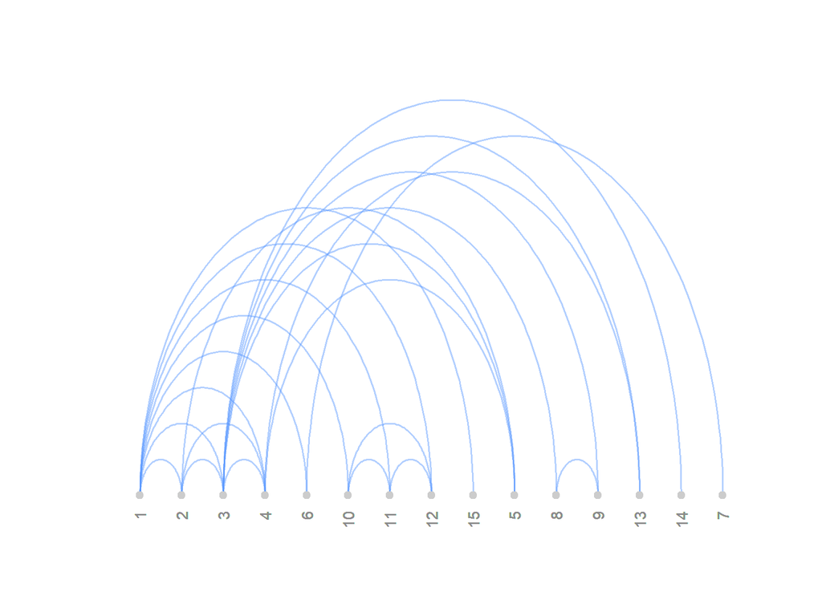

```r
data(Simpsons)
iSimp <- asIgraph(Simpsons)
simp_edge <- get.edgelist(iSimp)
arcplot(simp_edge)
```

Pentru a augmenta acest grafic, vom defini cateva subgrupuri in retea (1-familie; 2-colegi de munca; 3-colegi de scoala; 4-vecini) si vom folosi **culori diferite** pentru a distinge intre aceste categorii. De asemenea, folosim gradul unui nod pentru a obtine **marimea acestuia**.

[figure not shown]

```r
s_grp <- V(iSimp)$group
s_col = c("#a6611a", "#dfc27d","#80cdc1","#018571")
cols = s_col[s_grp]
node_deg <- degree(iSimp)

arcplot(simp_edge,
        lwd.arcs=2,
        cex.nodes=node_deg/2,
        labels=V(iSimp)$vertex.names,
        col.labels="darkgreen",
        font=1,
        pch.nodes=21,
        line=1,
        col.nodes = cols,
        bg.nodes = cols,
        show.nodes = TRUE)
```

#### **Diagrame de tip *chord***

Acest tip de diagrame specializate folosesc un layout circular care evidentiaza **inter-relatiile dintre datele stocate intr-o matrice**. Sunt potrivite, in special, pentru grafuri orientate si cu costuri, unde directia si cantitatea flow-urilor de date este de interes.

Exemplu: echipa de fotbal a Olandei din Campionatul Mondial din 2010. Pentru inceput, vom analiza **pasele** dintre cei 11 jucatori.

```r
data(FIFA_Nether)
FIFAm <- as.sociomatrix(FIFA_Nether,attrname='passes')
names <- c("GK1","DF3","DF4","DF5","MF6","FW7","FW9","MF10","FW11","DF2","MF8")
rownames(FIFAm) = names
colnames(FIFAm) = names
FIFAm
```

```
##      GK1 DF3 DF4 DF5 MF6 FW7 FW9 MF10 FW11 DF2 MF8
## GK1    0  42  67  21   2  27   7    5    2  17   3
## DF3   30   0  44  14  42  15   8    7   10  36  29
## DF4   38  43   0  57  18  11   7   21    1   7  28
## DF5    6  14  47   0  11  50  20   40    1   4  42
## MF6    9  28  25  10   0  41  28   37   14  34  21
## FW7    4  12   1  21  21   0  15   33    9  25  18
## FW9    0   0   1   8   7  12   0   31   16   7   2
## MF10   1  11  11  22  43  29  20    0   28  13  21
## FW11   3   2   2   3   7   6  11   15    0  21  12
## DF2   29  38   8   3  45  38  10   18   26   0  15
## MF8   12  25  26  38  23  13  12   32   11  24   0
```

Pentru ca graficul sa nu fie greu de citit, vom renunta la legaturile care au mai putin de 10 pase.

```r
FIFAm[FIFAm < 10] <- 0
FIFAm
```

```
##      GK1 DF3 DF4 DF5 MF6 FW7 FW9 MF10 FW11 DF2 MF8
## GK1    0  42  67  21   0  27   0    0    0  17   0
## DF3   30   0  44  14  42  15   0    0   10  36  29
## DF4   38  43   0  57  18  11   0   21    0   0  28
## DF5    0  14  47   0  11  50  20   40    0   0  42
## MF6    0  28  25  10   0  41  28   37   14  34  21
## FW7    0  12   0  21  21   0  15   33    0  25  18
## FW9    0   0   0   0   0  12   0   31   16   0   0
## MF10   0  11  11  22  43  29  20    0   28  13  21
## FW11   0   0   0   0   0   0  11   15    0  21  12
## DF2   29  38   0   0  45  38  10   18   26   0  15
## MF8   12  25  26  38  23  13  12   32   11  24   0
```

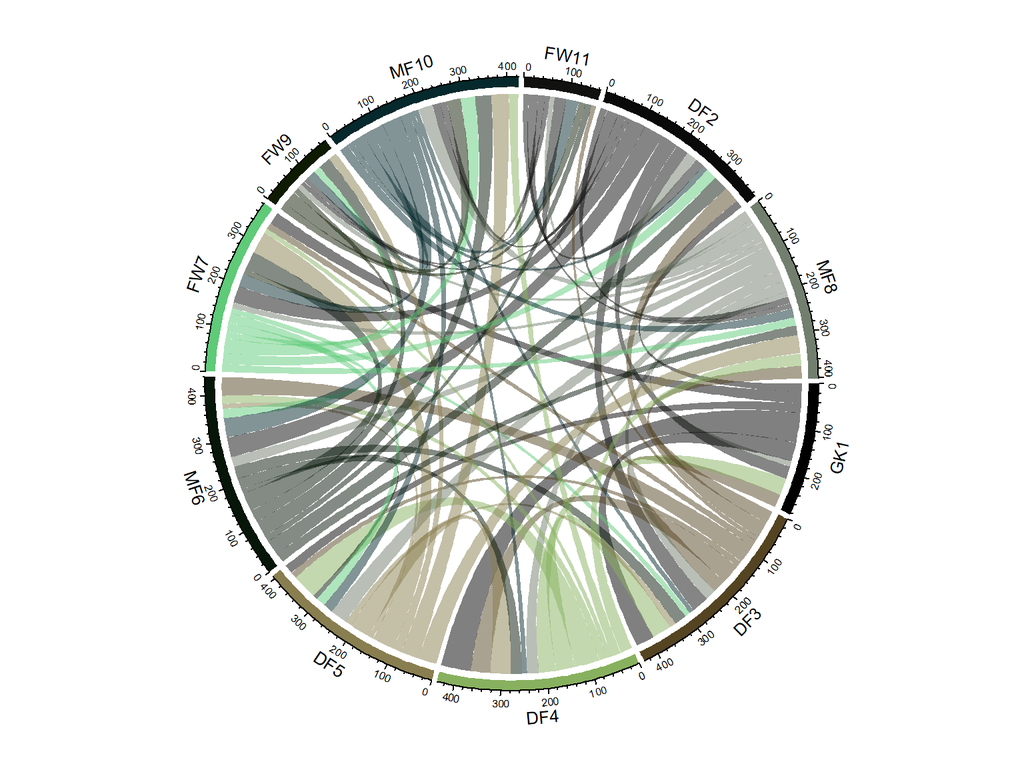

```r
chordDiagram(FIFAm)
```

Pentru a face graficul si mai sugestiv, vom modifica urmatoarele lucruri:

- jucatorii de pe aceeasi pozitie vor avea aceeasi culoare.
- optiunea *directional* face ca pasele care pleaca de la jucator sa inceapa mai departe de cercul exterior, facand usoara observarea diferentei dintre pasele date si cele primite.
- optiunea *order* sorteaza jucatorii in functie de pozitia acestora.

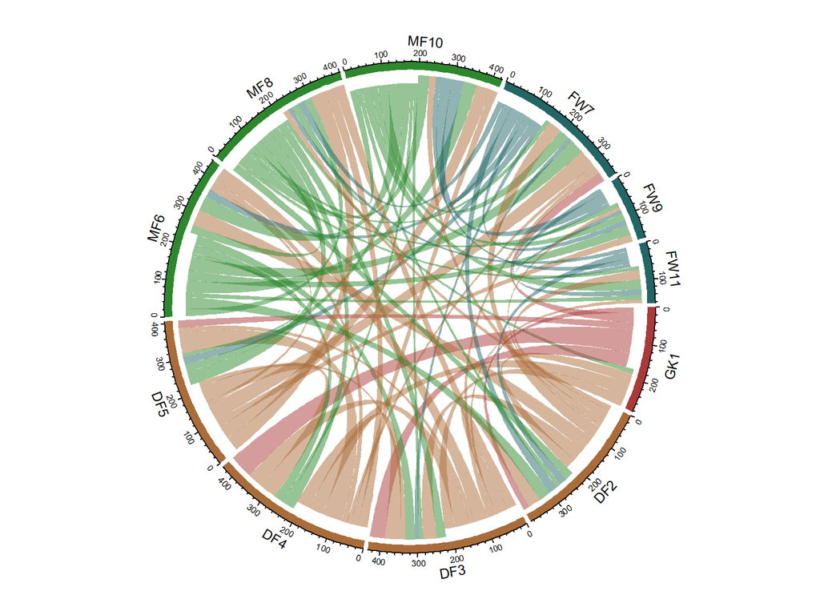

```r
grid.col <- c("#AA3939",rep("#AA6C39",4),rep("#2D882D",3),rep("#226666",3))
chordDiagram(FIFAm,
             directional = TRUE,
             grid.col = grid.col,
             order=c("GK1","DF2","DF3","DF4","DF5","MF6","MF8","MF10","FW7","FW9","FW11"))
```

Noi descoperiri:

- atacantul FW7 primeste de doua ori mai multe pase fata de ceilalti doi atacanti
- coechipierul favorit al portarului GK1 este fundasul DF4
- DF4 da pase frecvent la DF5.

#### **Heatmaps**

Acestea sunt o alta varianta de grafice specializate, utile, in special, atunci cand reteaua are costuri. In exemplul urmator, un astfel de grafic va evidentia jucatorii care ofera si primesc cele mai multe pase.

```r
data(FIFA_Nether)
FIFAm <- as.sociomatrix(FIFA_Nether,attrname='passes')
colnames(FIFAm) <- c("GK1","DF3","DF4","DF5","MF6","FW7","FW9","MF10","FW11","DF2","MF8")
rownames(FIFAm) <- c("GK1","DF3","DF4","DF5","MF6","FW7","FW9","MF10","FW11","DF2","MF8")
```

Reteaua fiind una orientata, consideram ca jucatorii care **dau pase** sunt randurile, iar coloanele sunt jucatorii care **primesc pase**.

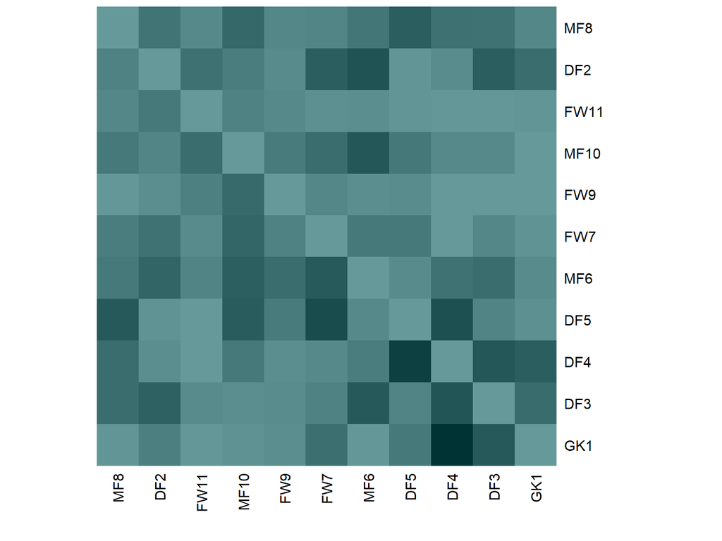

```r
palf <- colorRampPalette(c("#669999", "#003333"))
heatmap(FIFAm[,11:1],
        Rowv = NA,
        Colv = NA,
        col = palf(60),
        scale="none")
```